# Inequality and Segregation Lab 3

Author

Yukun Jiao

Published

December 1, 2025

```r
library(tidyverse)
library(ggforce)
library(cowplot)
library(RANN)
library(sf)
library(gt)
library(knitr)
library(kableExtra)

make_housing<-function(dim=100,n=10000,foci=c(0.2,0.8),noise=1,pow=2) {
  xy <-bind_rows(
    expand_grid( x=seq(0,dim)/dim, y=seq(0.5,dim-0.5)/dim ) ,
    expand_grid( x=seq(0.5,dim-0.5)/dim , y=seq(0,dim)/dim) )
  if(n>=nrow(xy)) {
    return(xy)
  }
  else {
    foci<-as_tibble(expand.grid(x_f=foci,y_f=foci))
    places<-expand_grid(xy,foci) |>
      mutate(d=sqrt((x-x_f)^2+(y-y_f)^2)) |>
      group_by(x,y) |>
      summarize(u=sum(1/(d+0.001)^pow)) |>
      ungroup() |>
      mutate(u=u/sd(u)) |>
      mutate(v = u + rnorm(n(),0,sd=noise)) |>
      filter(v>=sort(v,decreasing=T)[n]) |>
      select(x,y)
    return(places)
  }
}
```

# Modifying the Segregation Scenarios

## reducing to a single focus.

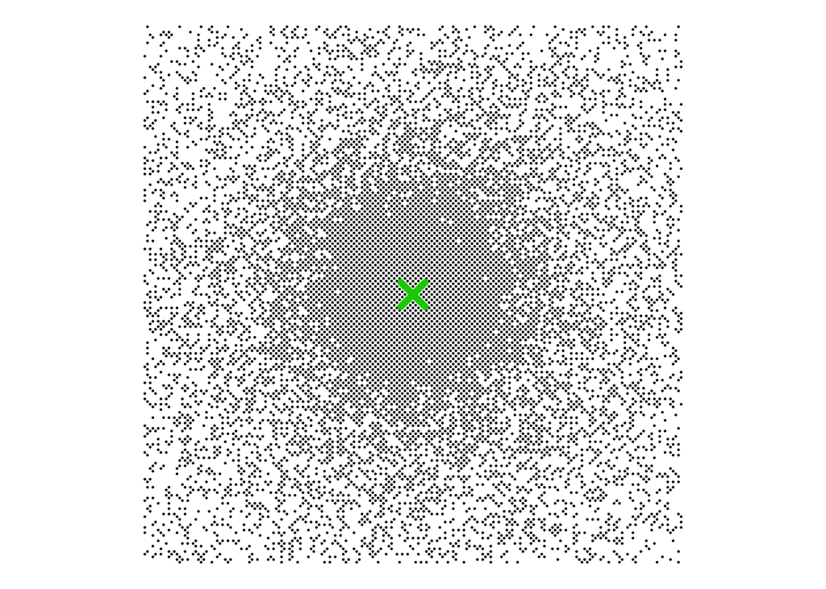

```r
foci<-as_tibble(expand.grid(x_f=c(0.5),y_f=c(0.5)))


places<-make_housing(pow=1,noise=0.5,foci=c(0.5),n=10000)
ggplot() +
  geom_point(data=places,aes(x=x,y=y),size=0.1) +
  geom_point(data=foci,aes(x=x_f,y=y_f),color="green3",size=5,shape=4,stroke=3) +
  theme_void() + coord_fixed()
```

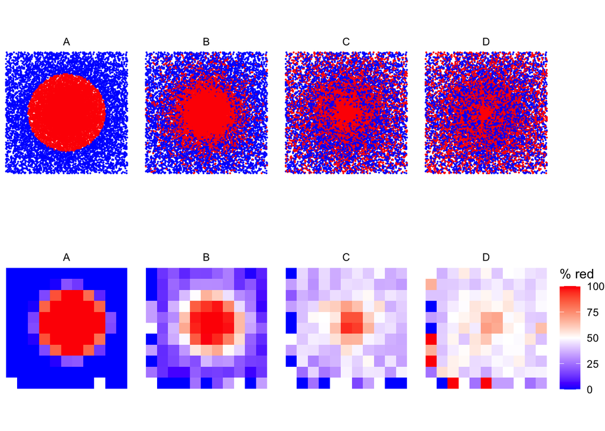

```r
places<-places |>
  expand_grid(foci) |>
  mutate(d=sqrt((x-x_f)^2+(y-y_f)^2)) |>
  mutate(u=1/d) |>
  group_by(x,y) |>
  summarize(u=sum(u)) |>
  ungroup() |> # do this so calculations aren't performed within combos of x & y
  mutate(C=u+rnorm(n=length(u),mean=0,sd=sd(u))) |>
  mutate(C=factor(ifelse(C>median(C),"red","blue"))) |>
  ungroup() |>
  mutate(A=u+rnorm(n=length(u),mean=0,sd=0*sd(u))) |>  # no noise!
  mutate(A=factor(ifelse(A>median(A),"red","blue"))) |>
  mutate(B=u+rnorm(n=length(u),mean=0,sd=0.2*sd(u))) |> # a bit of noise
  mutate(B=factor(ifelse(B>median(B),"red","blue"))) |>
  mutate(D=u+rnorm(n=length(u),mean=0,sd=3*sd(u))) |> # a lot of noise
  mutate(D=factor(ifelse(D>median(D),"red","blue")))


places <- places |> pivot_longer(cols=c("A","B","C","D"),
               names_to="city",
               values_to="group")

ggplot(data=slice(places,sample(1:nrow(places))), # random plot order
       aes(x=x,y=y,color=group)) +
  geom_point(size=0.1) +
  scale_color_identity() +
  coord_fixed() +
  theme_void() +
  theme(legend.position = "none", aspect.ratio = 1) +
  facet_grid(cols=vars(city)) -> gg_points

# gg_points

grid_dim<-10
blocks<-places |>
  mutate(x=ceiling(x*grid_dim)/grid_dim,y=ceiling(y*grid_dim)/grid_dim) |>
  group_by(city,x,y) |>
  summarize(red=sum(ifelse(group=="red",1,0)),
            blue=sum(ifelse(group=="blue",1,0))) |>
  mutate(`% red`=100*red/(red+blue))

ggplot(blocks,aes(x=x,y=y,fill=`% red`)) +
  geom_raster() +
  facet_grid(cols=vars(city)) +
  coord_fixed() +
  scale_fill_gradient2(midpoint=50,high="red",mid="white",low="blue") +
  theme_void() ->
  gg_blocks

plot_grid(gg_points,gg_blocks,nrow=2,align="hv",axis="r")
```

## Increasing the number of foci.

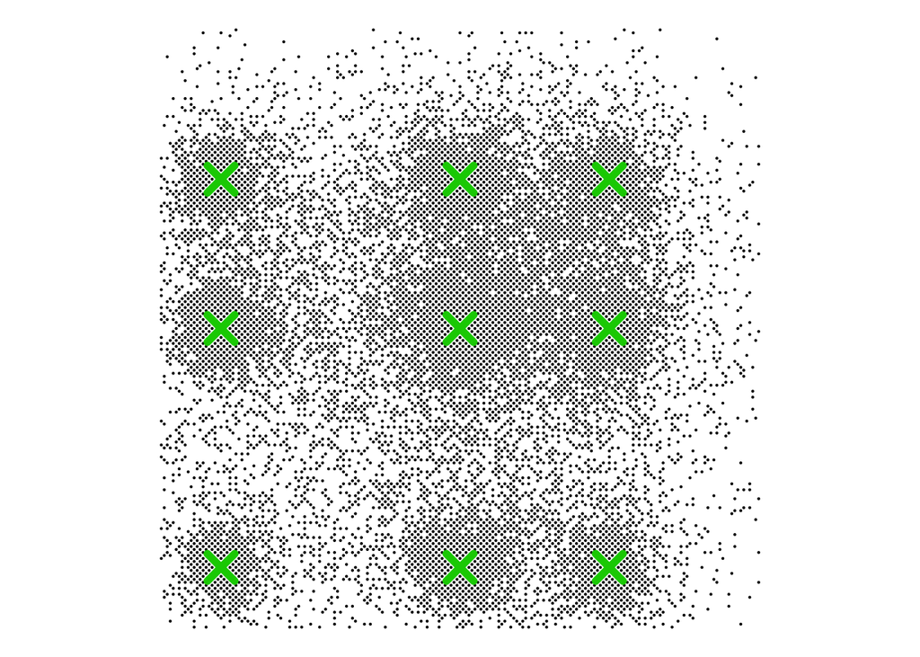

```r
foci<-as_tibble(expand.grid(x_f=c(0.1, 0.5, 0.75),y_f=c(0.1, 0.5, 0.75)))

places<-make_housing(pow=1,noise=0.5,foci=c(0.1, 0.5, 0.75),n=10000)
ggplot() +
  geom_point(data=places,aes(x=x,y=y),size=0.1) +
  geom_point(data=foci,aes(x=x_f,y=y_f),color="green3",size=5,shape=4,stroke=3) +
  theme_void() + coord_fixed()
```

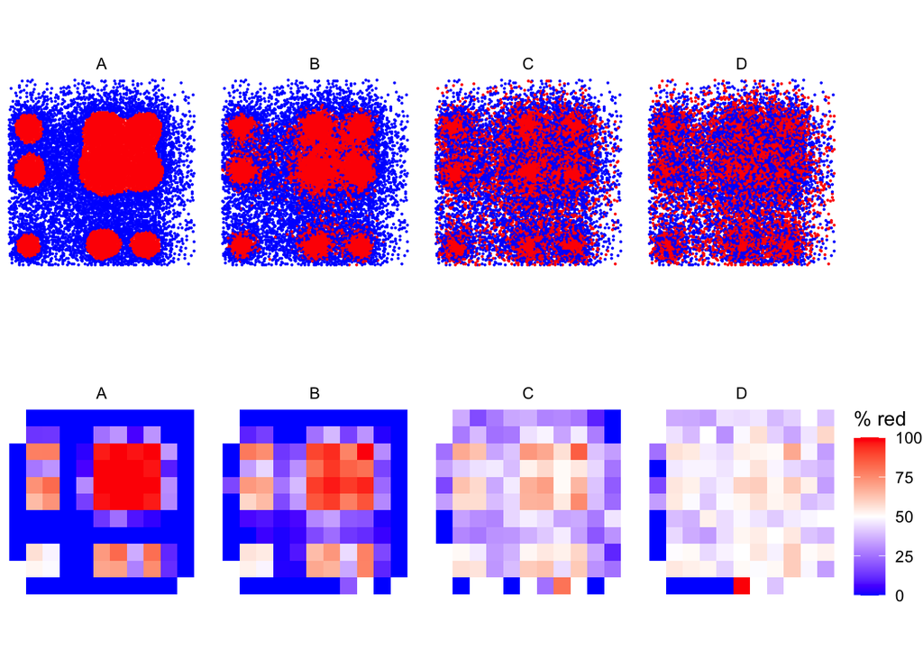

```r
places<-places |>
  expand_grid(foci) |>
  mutate(d=sqrt((x-x_f)^2+(y-y_f)^2)) |>
  mutate(u=1/d) |>
  group_by(x,y) |>
  summarize(u=sum(u)) |>
  ungroup() |> # do this so calculations aren't performed within combos of x & y
  mutate(C=u+rnorm(n=length(u),mean=0,sd=sd(u))) |>
  mutate(C=factor(ifelse(C>median(C),"red","blue"))) |>
  ungroup() |>
  mutate(A=u+rnorm(n=length(u),mean=0,sd=0*sd(u))) |>  # no noise!
  mutate(A=factor(ifelse(A>median(A),"red","blue"))) |>
  mutate(B=u+rnorm(n=length(u),mean=0,sd=0.2*sd(u))) |> # a bit of noise
  mutate(B=factor(ifelse(B>median(B),"red","blue"))) |>
  mutate(D=u+rnorm(n=length(u),mean=0,sd=3*sd(u))) |> # a lot of noise
  mutate(D=factor(ifelse(D>median(D),"red","blue")))

places <- places |> pivot_longer(cols=c("A","B","C","D"),
               names_to="city",
               values_to="group")

ggplot(data=slice(places,sample(1:nrow(places))), # random plot order
       aes(x=x,y=y,color=group)) +
  geom_point(size=0.1) +
  scale_color_identity() +
  coord_fixed() +
  theme_void() +
  theme(legend.position = "none", aspect.ratio = 1) +
  facet_grid(cols=vars(city)) -> gg_points

# gg_points


grid_dim<-10
blocks<-places |>
  mutate(x=ceiling(x*grid_dim)/grid_dim,y=ceiling(y*grid_dim)/grid_dim) |>
  group_by(city,x,y) |>
  summarize(red=sum(ifelse(group=="red",1,0)),
            blue=sum(ifelse(group=="blue",1,0))) |>
  mutate(`% red`=100*red/(red+blue))

ggplot(blocks,aes(x=x,y=y,fill=`% red`)) +
  geom_raster() +
  facet_grid(cols=vars(city)) +
  coord_fixed() +
  scale_fill_gradient2(midpoint=50,high="red",mid="white",low="blue") +
  theme_void() ->
  gg_blocks

plot_grid(gg_points,gg_blocks,nrow=2,align="hv",axis="r")
```

## Changing the spatial distribution of the foci.

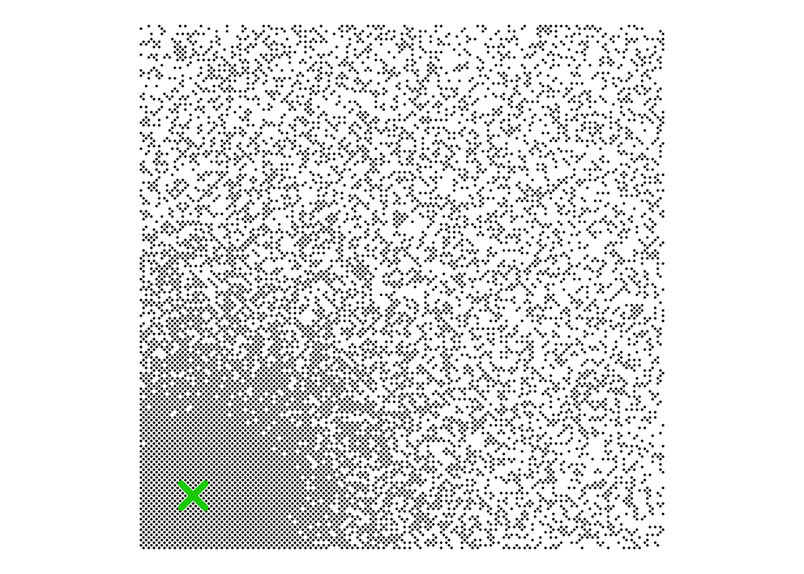

```r
foci<-as_tibble(expand.grid(x_f=c(0.1),y_f=c(0.1)))

places<-make_housing(pow=1,noise=0.5,foci=c(0.1),n=10000)
ggplot() +
  geom_point(data=places,aes(x=x,y=y),size=0.1) +
  geom_point(data=foci,aes(x=x_f,y=y_f),color="green3",size=5,shape=4,stroke=3) +
  theme_void() + coord_fixed()
```

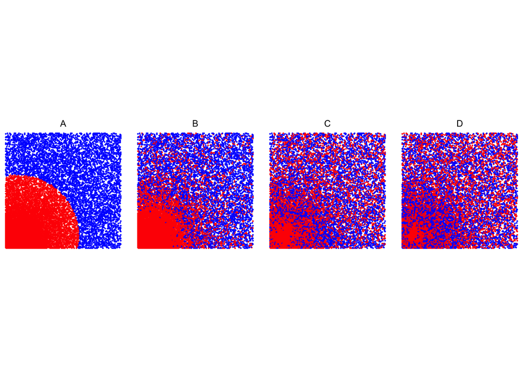

```r
places<-places |>
  expand_grid(foci) |>
  mutate(d=sqrt((x-x_f)^2+(y-y_f)^2)) |>
  mutate(u=1/d) |>
  group_by(x,y) |>
  summarize(u=sum(u)) |>
  ungroup() |> # do this so calculations aren't performed within combos of x & y
  mutate(C=u+rnorm(n=length(u),mean=0,sd=sd(u))) |>
  mutate(C=factor(ifelse(C>median(C),"red","blue"))) |>
  ungroup() |>
  mutate(A=u+rnorm(n=length(u),mean=0,sd=0*sd(u))) |>  # no noise!
  mutate(A=factor(ifelse(A>median(A),"red","blue"))) |>
  mutate(B=u+rnorm(n=length(u),mean=0,sd=0.2*sd(u))) |> # a bit of noise
  mutate(B=factor(ifelse(B>median(B),"red","blue"))) |>
  mutate(D=u+rnorm(n=length(u),mean=0,sd=3*sd(u))) |> # a lot of noise
  mutate(D=factor(ifelse(D>median(D),"red","blue")))

# ggplot(places,aes(x=x,y=y,color=C)) +
#   geom_point() +
#   scale_color_identity() +
#   theme_void() +
#   coord_fixed() +
#   theme(legend.position = "none")

places <- places |> pivot_longer(cols=c("A","B","C","D"),
               names_to="city",
               values_to="group")

ggplot(data=slice(places,sample(1:nrow(places))), # random plot order
       aes(x=x,y=y,color=group)) +
  geom_point(size=0.1) +
  scale_color_identity() +
  coord_fixed() +
  theme_void() +
  theme(legend.position = "none", aspect.ratio = 1) +
  facet_grid(cols=vars(city)) -> gg_points
gg_points
```

# Evenness and exposure measures of segregation

## Confirm that the index of dissimilarity obeys composition invariance principle by doubling the size of the “red” population in each neighborhood and re-calculating the indices.

```r
calcD <- function(x,y) {
  result<-0.5*sum(abs(x/sum(x)-y/sum(y)))
  return(result)
}

grid_dim<-10
blocks<-places |>
  mutate(x=ceiling(x*grid_dim)/grid_dim,y=ceiling(y*grid_dim)/grid_dim) |>
  group_by(city,x,y) |>
  summarize(red=sum(ifelse(group=="red",1,0)),
            blue=sum(ifelse(group=="blue",1,0))) |>
  mutate(`% red`=100*red/(red+blue))


D0 <- blocks |>
  group_by(city) |>
  summarize(D = calcD(red, blue), .groups="drop")

blocks_red2 <- blocks |> mutate(red = 2*red)

D1 <- blocks_red2 |>
  group_by(city) |>
  summarize(D = calcD(red, blue), .groups="drop")
```

```r
left_join(D0, D1, by="city", suffix=c("_orig","_red2")) |>
  gt() |>
  fmt_number(everything(), decimals = 3)
```

Dissimilarity index before and after doubling the red population

| city | D_orig | D_red2 |
| --- | --- | --- |
| A | 0.950 | 0.950 |
| B | 0.554 | 0.554 |
| C | 0.245 | 0.245 |
| D | 0.131 | 0.131 |

Doubling the size of the red population does not change the value of the dissimilarity index. This confirms that the dissimilarity index satisfies the composition invariance principle.

## Does the two group information theory index fulfill the composition invariance principle?

```r
calcH <- function(...) { # vectors or dataframe for the group counts
  t.jm<-cbind(...)      # bind together the group counts
  t.j<-rowSums(t.jm)    # count in each neighborhood
  T<-sum(t.jm)        # total population count
  M<-ncol(t.jm)         # count the number of groups (columns)
  p.m<-colSums(t.jm)/T # calculate the population proportions
  E<-sum(p.m*log(1/p.m,M),na.rm=TRUE) # population entropy
  p.jm<-t.jm/t.j        # neighborhood-level proportions
  E.j<-rowSums(p.jm*log(1/p.jm,M),na.rm=TRUE) # neighborhood entropies
  H<-1/(T*E)*sum(t.j*(E-E.j)) # H
  return(H)
}

H0 <- blocks |> group_by(city) |> summarize(H = calcH(red, blue))
H1 <- blocks_red2 |> group_by(city) |> summarize(H = calcH(red, blue))
```

```r
left_join(H0, H1, by="city", suffix=c("_orig","_red2")) |>
  gt() |>
  fmt_number(everything(), decimals = 3)
```

Information theory index (H) before vs. after doubling the red population

| city | H_orig | H_red2 |
| --- | --- | --- |
| A | 0.921 | 0.918 |
| B | 0.344 | 0.319 |
| C | 0.084 | 0.078 |
| D | 0.022 | 0.021 |

## Demonstrate that the exposure and isolation indices are not compositionally invariant.

```r
expo0 <- blocks |>
  group_by(city) |>
  summarize(
    P_RR = weighted.mean(red/(red+blue),  w = red),   # isolation of red
    P_RB = weighted.mean(blue/(red+blue), w = red),   # exposure red->blue
    .groups = "drop"
  )


blocks_red2 <- blocks |> mutate(red = 2*red)

expo1 <- blocks_red2 |>
  group_by(city) |>
  summarize(
    P_RR = weighted.mean(red/(red+blue),  w = red),
    P_RB = weighted.mean(blue/(red+blue), w = red),
    .groups = "drop"
  )

expo_diff <- left_join(expo0, expo1, by="city", suffix=c("_orig","_red2")) |>
  transmute(
    City = city,
    diff_PRR = P_RR_red2 - P_RR_orig,
    diff_PRB = P_RB_red2 - P_RB_orig
  )
```

```r
expo_diff |>
  gt() |>
  fmt_number(everything(), decimals = 3)
```

Change in exposure/isolation after doubling the red population

| City | diff_PRR | diff_PRB |
| --- | --- | --- |
| A | 0.010 | −0.010 |
| B | 0.082 | −0.082 |
| C | 0.142 | −0.142 |
| D | 0.160 | −0.160 |

The table above shows that the exposure and isolation indices are not compositionally invariant.

# Experimenting with spatial segregation indices

## What happens to the segregation index as you increase or decrease the number of nearest neighbors that are considered?

```r
nn_bespoke<-function(g,x,y,k=10,searchtype="standard",radius=0) {
  knn<-nn2(data=cbind(x,y),k=k,searchtype=searchtype,radius=radius)
  x<-knn$nn.idx
  lapply(seq_len(nrow(x)), function(i) x[i,]) |>
    lapply(function(x) `[`(g,x)) |>
    lapply(table) |>
    bind_rows() |>
    mutate(across(everything(),as.integer))
}

k_grid <- c(5, 20)
expo_by_k <- lapply(k_grid, function(k){
  places |>
    group_by(city) |>
    mutate(nn_bespoke(group, x, y, k = k)) |>
    group_by(city, group) |>
    summarize(P_red = mean(red/k), P_blue = mean(blue/k), .groups="drop") |>
    mutate(k = k)
}) |>
  bind_rows()

expo_by_k_A <- expo_by_k |>
  filter(city == "A")
# expo_by_k |> arrange(k, city, group) |> arrange(k, city) |>
#   gt() |>
#   fmt_number(everything(), decimals = 3)
```

```r
# expo_by_k_A |>
#   filter(group=="blue") |>
#   arrange(k, city) |>
#   gt() |>
#   fmt_number(everything(), decimals = 3)
```

```r
tab_P_RR <- expo_by_k_A %>%
  filter(group == "red") %>%
  select(city, k, P_RR = P_red) %>%
  pivot_wider(names_from = k, values_from = P_RR, names_prefix = "k=") %>%
  arrange(city)

tab_P_BR <- expo_by_k_A %>%
  filter(group == "blue") %>%
  select(city, k, P_BR = P_red) %>%
  pivot_wider(names_from = k, values_from = P_BR, names_prefix = "k=") %>%
  arrange(city)
```

```r
tab_P_RR |>
  gt() |>
  fmt_number(everything(), decimals = 3)
```

Red isolation (P_RR) by neighborhood size (k)

| city | k=5 | k=20 |
| --- | --- | --- |
| A | 0.995 | 0.990 |

```r
tab_P_BR |>
  gt() |>
  fmt_number(everything(), decimals = 3)
```

Blue-to-red exposure (P_BR) by neighborhood size (k)

| city | k=5 | k=20 |
| --- | --- | --- |
| A | 0.005 | 0.011 |

With the number $k$ increasing, measured segregation decreases. Larger $k$ averages over broader neighborhoods, smoothing local differences.

## Does the index work as you expect for the different city scenarios? How do the values compare for City A vs. B vs. C vs. D?

```r
expo_by_k |>
  filter(group=="blue") |>
  arrange(k, city) |>
  gt() |>
  fmt_number(everything(), decimals = 3)
```

Blue group neighborhood composition across cities and k

| city | group | P_red | P_blue | k |
| --- | --- | --- | --- | --- |
| A | blue | 0.005 | 0.995 | 5.000 |
| B | blue | 0.243 | 0.757 | 5.000 |
| C | blue | 0.359 | 0.641 | 5.000 |
| D | blue | 0.387 | 0.613 | 5.000 |
| A | blue | 0.011 | 0.989 | 20.000 |
| B | blue | 0.289 | 0.711 | 20.000 |
| C | blue | 0.427 | 0.573 | 20.000 |
| D | blue | 0.464 | 0.536 | 20.000 |

```r
#
# tab_P_RR <- expo_by_k %>%
#   filter(group == "red") %>%
#   select(city, k, P_RR = P_red) %>%
#   pivot_wider(names_from = k, values_from = P_RR, names_prefix = "k=") %>%
#   arrange(city)
#
# tab_P_BR <- expo_by_k %>%
#   filter(group == "blue") %>%
#   select(city, k, P_BR = P_red) %>%
#   pivot_wider(names_from = k, values_from = P_BR, names_prefix = "k=") %>%
#   arrange(city)

# tab_P_RR |>
#   gt() |>
#   fmt_number(everything(), decimals = 3)

# tab_P_BR |>
#   gt() |>
#   fmt_number(everything(), decimals = 3)
```

Yes. Across all neighborhood sizes, segregation is highest in City A, followed by B, C, and D. This ordering matches the increasing level of noise introduced in each scenario.

## How do the values of the spatial dissimilarity index vary across the different cities as you increase or decrease the number of nearest neighbors?

```r
calcD<-function(g,...) {
  p.j<-cbind(...)
  p.j<-p.j/rowSums(p.j)
  p<-table(g)
  T<-sum(p)
  p<-p/T
  nms<-names(p)
  result<-1/(2*T)*sum(abs(p.j[,nms[1]]/p[1] - p.j[,nms[2]]/p[2]))
  return(result)
}

spatial_dissimilarity <- function(city_name = "A", k_num = 10) {
  city<-filter(places,city==city_name)
  knn_nbhd<-nn2(data=city[,c("x","y")],k=k_num)

  x<-knn_nbhd$nn.idx
  x<-lapply(seq_len(nrow(x)), function(i) x[i,])

  g<-pull(city,group)
  x<-lapply(x,function(x) `[`(g,x))
  bespoke<-lapply(x,table) |>
      bind_rows() |>
     mutate(across(everything(),as.integer))
  bespoke_city<-bind_cols(city,bespoke)
  bespoke_city |> summarize(D=calcD(group,red,blue))
}
```

```r
cities <- c("A","B","C","D")
ks <- c(5, 10, 20)
grid <- tidyr::expand_grid(city = cities, k = ks)

sd_all <- grid |>
  rowwise() |>
  mutate(D = spatial_dissimilarity(city, k)$D) |>
  ungroup()
```

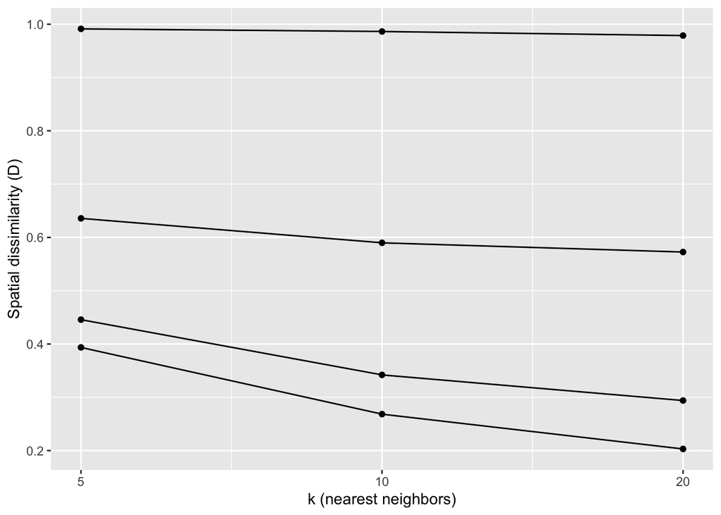

Spatial dissimilarity of Each City

```r
ggplot(sd_all, aes(x = k, y = D, group = city)) +
  geom_line() +
  geom_point() +
  scale_x_continuous(trans = "log10") +
  labs(x = "k (nearest neighbors)", y = "Spatial dissimilarity (D)")
```